# Stat 184 Final Project

Lucas Wolf

December 14, 2020

### Required Packages Before Running

```r
library(genius)
library(tidyverse)
library(tidytext)
library(rvest)
library(qdap)
library(gridExtra)
library(lattice)
```

```r
webpage <- read_html("https://en.wikipedia.org/wiki/Grammy_Award_for_Record_of_the_Year")

Xpath1980 <- '/html/body/div[3]/div[3]/div[5]/div[1]/table[5]'

Xpath1990 <- '/html/body/div[3]/div[3]/div[5]/div[1]/table[6]'

Xpath2000 <- '/html/body/div[3]/div[3]/div[5]/div[1]/table[7]'

Xpath2010 <- '/html/body/div[3]/div[3]/div[5]/div[1]/table[8]'
```

### Putting the Data From The Webpage Into Tables

```r
Table_1980 <-
  webpage %>%
  html_nodes(xpath = Xpath1980) %>%
  html_table(fill = TRUE)

Table_1990 <-
  webpage %>%
  html_nodes(xpath = Xpath1990) %>%
  html_table(fill = TRUE)

Table_2000 <-
  webpage %>%
  html_nodes(xpath = Xpath2000) %>%
  html_table(fill = TRUE)

Table_2010 <-
  webpage %>%
  html_nodes(xpath = Xpath2010) %>%
  html_table(fill = TRUE)
```

### Cleaning Up The Data

In order to do this, I removed the [I] from the end of the year category header, removed the (s) out of the artist header, changed Production team to production, and changed Record to record. In the actual cases of data, I removed the numbers in brackets following the years. This allows for the years to be easily put into decade categories later in the project, and cleans up the data overall. Finally the add_genius line at the end is used to add the lyrics to the songs. This process is repeated through the next decades in t1990, t2000, and t2010.

```r
T1980 = Table_1980[[1]]

T1980 <-
  T1980 %>%
  mutate(`Year[I]` = gsub(pattern = ".[0-9][0-9].$", replacement = "", `Year[I]`)) %>%
  rename(year = `Year[I]`,
         record = Record,
         artist = `Artist(s)`,
         production = `Production team`) %>%
  add_genius(artist, record, type = "lyrics")
```

### Removing Stop Words

First, I created a variable with the rest of the stop words needed that were not included in the original stop_words data. The verse_words1980 table puts all of the words into their own cases through the unnest_tokens function, and then creates a variable decade for the table. ft80 then removes the original stop words data frame words from the data frame with the lyrics of the 1980 grammy nominated songs. stop_words1 is a data frame that contains filters out every words but the words contained in the stop variable, and then finally those words are filtered out of the ft80 data frame as well. This process is repeated for the next 3 graphs for the following decades, ft90, ft00, ft10

```r
stop = "ba|du|yeah|da|ya|ooh|gonna|na|uh|la|hol"
Verse_words1980 <- T1980 %>%
  unnest_tokens(word, lyric) %>%
  mutate(decade = "1980s")

Ft80 <- Verse_words1980 %>%
  anti_join(stop_words)

Stop_words1 <- Ft80 %>%
  group_by(word) %>%
  filter(grepl(word, stop))

Ft80 <- Ft80 %>%
  anti_join(Stop_words1)
```

### Cleaning Data From 1990

```r
T1990 = Table_1990[[1]]

T1990 <-
  T1990 %>%
  mutate(`Year[I]` = gsub(pattern = ".[0-9][0-9].$", replacement = "", `Year[I]`)) %>%
  rename(year = `Year[I]`,
         record = Record,
         artist = `Artist(s)`,
         production = `Production team`) %>%
  add_genius(artist, record, type = "lyrics")
```

### Removing Stop Words From 1990

```r
Verse_words1990 <- T1990 %>%
  unnest_tokens(word, lyric) %>%
  mutate(decade = "1990s")

Ft90 <- Verse_words1990 %>%
  anti_join(stop_words)

Stop_words2 <- Ft90 %>%
  group_by(word) %>%
  filter(grepl(word, stop))

Ft90 <- Ft90 %>%
  anti_join(Stop_words2)
```

### Cleaning Data From 2000

```r
T2000 = Table_2000[[1]]

T2000 <-
  T2000 %>%
  mutate(`Year[I]` = gsub(pattern = ".[0-9][0-9].$", replacement = "", `Year[I]`)) %>%
  rename(year = `Year[I]`,
         record = Record,
         artist = `Artist(s)`,
         production = `Production team`) %>%
  add_genius(artist, record, type = "lyrics")
```

### Removing Stop Words From 2000

```r
Verse_words2000 <- T2000 %>%
  unnest_tokens(word, lyric) %>%
  mutate(decade = "2000s")

Ft00 <- Verse_words2000 %>%
  anti_join(stop_words)

Stop_words3 <- Ft00 %>%
  group_by(word) %>%
  filter(grepl(word, stop))

Ft00 <- Ft00 %>%
  anti_join(Stop_words3)
```

### Cleaning Data From 2010

```r
T2010 = Table_2010[[1]]

T2010 <-
  T2010 %>%
  mutate(`Year[I]` = gsub(pattern = ".[0-9][0-9].$", replacement = "", `Year[I]`)) %>%
  rename(year = `Year[I]`,
         record = Record,
         artist = `Artist(s)`,
         production = `Production team`) %>%
  add_genius(artist, record, type = "lyrics")
```

### Removing Stop Words From 2010

```r
Verse_words2010 <- T2010 %>%
  unnest_tokens(word, lyric) %>%
  mutate(decade = "2010s")

Ft10 <- Verse_words2010 %>%
  anti_join(stop_words)

Stop_words4 <- Ft10 %>%
  group_by(word) %>%
  filter(grepl(word, stop))

Ft10 <- Ft10 %>%
  anti_join(Stop_words4)
```

### Creating Data Frame GrammyAwardsNoStop For The List of Words From 1980-2019 Without Removing the Stop Words

```r
GrammyAwardNoStop <-
  full_join(Verse_words1980, Verse_words1990)
GrammyAwardNoStop <-
  full_join(GrammyAwardNoStop, Verse_words2000)
GrammyAwardNoStop <-
  full_join(GrammyAwardNoStop, Verse_words2010)
```

### Getting the Amount of Words Per Song

```r
GrammyAwardNoStop <-
  GrammyAwardNoStop %>%
    group_by(decade, record) %>%
    summarise(count = n())
```

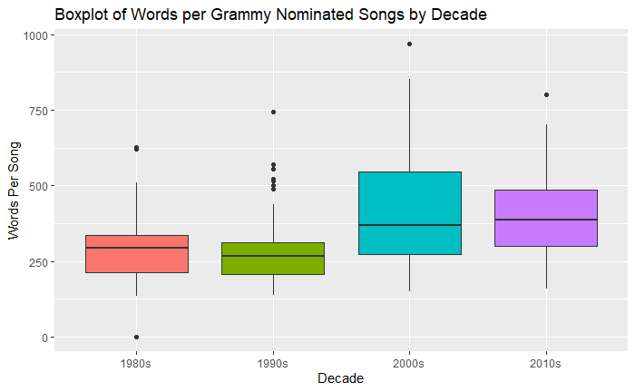

```r
ggplot(GrammyAwardNoStop) +
  aes(x = decade, y = count) +
  geom_boxplot(aes(fill = decade), show.legend = F) +
  labs(x = "Decade", y = "Words Per Song", title = "Boxplot of Words per Grammy Nominated Songs by Decade")
```

### Interpretation Graph 1

This data visualization shows a boxplot of the amount of words per Grammy nominated songs. From the 1990s on, the average number of words per song saw an increase between the following decades, with the mean jumping up about 100 more words per song from the 1990s to the 2000s. The 1990s have the lowest IQR so they has the least variability between songs, while the 2000s has the largest IQR with the most variability. The 1980s contains the Grammy nominated song with the least amount of words (close to 0) and the 2000s has the Grammy nominated song with the most words with about 950 words.

### Creating Data Frame GrammyAwardStop as Words From Grammy Nominated Songs From 1980-2019 With Stop Words Filtered Out

```r
GrammyAwardStop <-
  full_join(Ft80, Ft90)
GrammyAwardStop <-
  full_join(GrammyAwardStop, Ft00)
GrammyAwardStop <-
  full_join(GrammyAwardStop, Ft10)
```

```r
PopularWords <-
  GrammyAwardStop %>%
  group_by(word) %>%
  summarise(count = n()) %>%
  top_n(10) %>%
  arrange(desc(count))
```

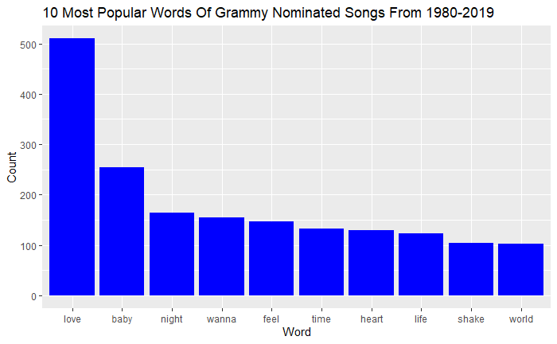

```r
ggplot(PopularWords) +
 geom_bar(fill = 'blue', aes(x = reorder(word, -count), weight = count)) +
 labs(x = "Word", y = "Count", title = "10 Most Popular Words Of Grammy Nominated Songs From 1980-2019")
```

### Interpretation of Graph 2

This graph shows the 10 most popular words of Grammy nominated songs from 1980 all the way to 2019. Showing that words like love, baby, night, feel, heart, life make up more than half of the top 10 words, a lot of the Grammy nominated songs talk about or include sentimental ideas. All of these words can be used in a sentimental way which leads me to believe that a lot of the songs that were popular in these eras had to do with love.

### Making a Data Frame For Each Decade and Their Top 10 Most Popular Words

```r
PopularWords80 <-
  GrammyAwardStop %>%
  group_by(word, decade)%>%
  filter(decade == "1980s") %>%
  summarise(count = n()) %>%
  arrange(desc(count)) %>%
  head(10)

PopularWords90 <-
  GrammyAwardStop %>%
  group_by(word, decade)%>%
  filter(decade == "1990s") %>%
  summarise(count = n()) %>%
  arrange(desc(count)) %>%
  head(10)

PopularWords00 <-
  GrammyAwardStop %>%
  group_by(word, decade)%>%
  filter(decade == "2000s") %>%
  summarise(count = n()) %>%
  arrange(desc(count)) %>%
  head(10)

PopularWords10 <-
  GrammyAwardStop %>%
  group_by(word, decade)%>%
  filter(decade == "2010s") %>%
  summarise(count = n()) %>%
  arrange(desc(count)) %>%
  head(10)
```

### Makes The 4 Seperate Graphs of the Most Popular Words Per Decade And Combines Them Into One Grid Using grid.arrange

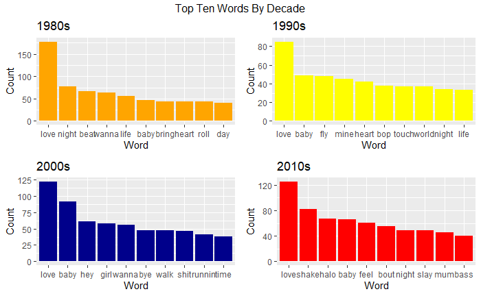

```r
PopularSongs80 <-
ggplot(PopularWords80) +
 geom_bar(fill = 'orange', aes(x = reorder(word, -count), weight = count)) +
 labs(x = "Word", y = "Count", title = "1980s")

PopularSongs90 <-
ggplot(PopularWords90) +
 geom_bar(fill = 'yellow', aes(x = reorder(word, -count), weight = count)) +
 labs(x = "Word", y = "Count", title = "1990s")

PopularSongs00 <-
ggplot(PopularWords00) +
 geom_bar(fill = 'darkblue', aes(x = reorder(word, -count), weight = count)) +
 labs(x = "Word", y = "Count", title = "2000s")

PopularSongs10 <-
ggplot(PopularWords10) +
 geom_bar(fill = 'red', aes(x = reorder(word, -count), weight = count)) +
 labs(x = "Word", y = "Count", title = "2010s")

grid.arrange(PopularSongs80, PopularSongs90, PopularSongs00, PopularSongs10, nrow = 2, top = "Top Ten Words By Decade")
```

```r
SentimentWords <-
  full_join(GrammyAwardStop, sentiments)
```

### Changes the Words Into Numeric Values In the SentimentWords Data Frame

```r
SentimentWords <-
  SentimentWords %>%
  mutate(sentiment = gsub(pattern = "negative", replacement = "0", sentiment)) %>%
  mutate(sentiment = gsub(pattern = "positive", replacement = "1", sentiment))
```

### Giving a different sentiment score by year

```r
SentimentWords80 <-
  SentimentWords %>%
  group_by(sentiment, year, decade)%>%
  filter(grepl("198.", year)) %>%
  summarise(count = n()) %>%
  arrange(desc(count))

SentimentWords90 <-
  SentimentWords %>%
  group_by(sentiment, year, decade)%>%
  filter(grepl("199.", year)) %>%
  summarise(count = n()) %>%
  arrange(desc(count))

SentimentWords00 <-
  SentimentWords %>%
  group_by(sentiment, year, decade)%>%
  filter(grepl("200.", year)) %>%
  summarise(count = n()) %>%
  arrange(desc(count))

SentimentWords10 <-
  SentimentWords %>%
  group_by(sentiment, year, decade)%>%
  filter(grepl("201.", year)) %>%
  summarise(count = n()) %>%
  arrange(desc(count))
```

### Arranging them into the one larger data frame

```r
SentiWordsTotal <-
  full_join(SentimentWords80, SentimentWords90)
SentiWordsTotal <-
  full_join(SentiWordsTotal, SentimentWords00)
SentiWordsTotal <-
  full_join(SentiWordsTotal, SentimentWords10) %>%
  filter(sentiment == "1") %>%
  arrange(year)
```

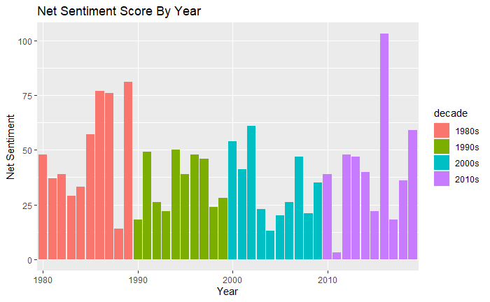

```r
ggplot(SentiWordsTotal) +
 aes(x = year, fill = decade, weight = count) +
 geom_bar() +
 labs(x = "Year", y = "Net Sentiment", title = "Net Sentiment Score By Year") +
 scale_x_discrete(breaks = c(1980, 1990, 2000, 2010))
```

### Interpretation Graph 4

In the graph of the net sentiment score per year, the amount of sentiment per year moves around a lot. With a lone peak in 2016 that does not have any trend with it, shows that maybe these sentimental songs are more sporadic than going along with the decades. In the same decade with the 2010s, they also have the lowest amount of sentiment words in 2011 for the entire 39 year span. In the late 1980s, there is a big spike in sentiment words in 86 and 87 and then a sudden plunge to barely any in 88. After this low, the numbers soar back up to the second highest peak, showing that the amount of sentiment is sporadic for Grammy nominated songs.

### Making 4 Seperate Data Frames Finding the Mean Sentiment Score By Decade

```r
SentiWordsGraph5.0 <-
  SentimentWords80 %>%
  filter(sentiment == "1") %>%
  group_by(decade) %>%
  summarise(mean(count))

SentiWordsGraph5.1 <-
  SentimentWords90 %>%
  filter(sentiment == "1") %>%
  group_by(decade) %>%
  summarise(mean(count))

SentiWordsGraph5.2 <-
  SentimentWords00 %>%
  filter(sentiment == "1") %>%
  group_by(decade) %>%
  summarise(mean(count))

SentiWordsGraph5.3 <-
  SentimentWords10 %>%
  filter(sentiment == "1") %>%
  group_by(decade) %>%
  summarise(mean(count))
```

### Creating Full Data Frame With All Decades and Their Means

```r
SentiWordsGraph5 <-
  full_join(SentiWordsGraph5.0, SentiWordsGraph5.1)
SentiWordsGraph5 <-
  full_join(SentiWordsGraph5, SentiWordsGraph5.2)
SentiWordsGraph5 <-
  full_join(SentiWordsGraph5, SentiWordsGraph5.3)
```

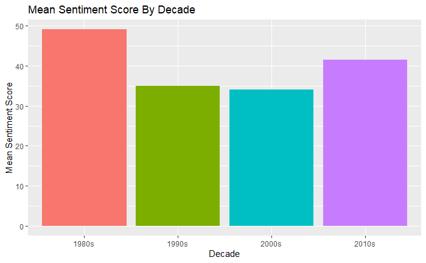

```r
ggplot(SentiWordsGraph5) +
 aes(x = decade, fill = decade, weight = `mean(count)`) +
 geom_bar(show.legend = F) +
 scale_fill_hue() +
 labs(x = "Decade", y = "Mean Sentiment Score", title = "Mean Sentiment Score By Decade")
```

### Interpretation 5

The mean sentiment score by decade shows that the 1980s have the highest average sentiment amount, followed by the 2010s, and followed by the almost identical 1990s and 2000s. This shows that people really enjoyed sentimental music in the 1980s, and then once the 90s came around people did not really care for this sort of music until the 2010s came around.

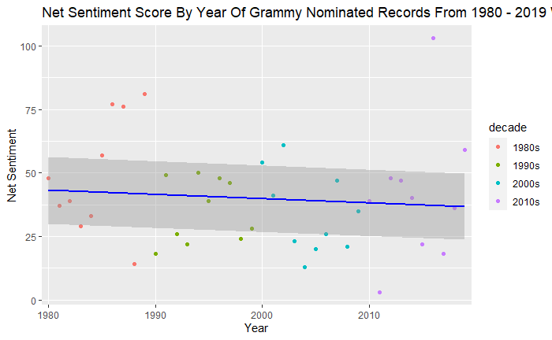

```r
ggplot(SentiWordsTotal) +
 aes(x = year, color = decade, y = count) +
 geom_point() +
 scale_x_discrete(breaks = c(1980, 1990, 2000, 2010)) +
 geom_smooth(method = lm, na.rm = TRUE, fullrange= TRUE,
               aes(group=1),colour="blue") +
 labs(x = "Year", y = "Net Sentiment", title = "Net Sentiment Score By Year Of Grammy Nominated Records From 1980 - 2019 With Linear Model Fit")
```

### Presentation Of Graphs

https://psu.zoom.us/rec/share/V5TR-T4STnH7tjZame3ZzmRFIjhG-muDb7WQp4Y37k7lwcSvouJ0viaXkiBr_PsY.dy7Qz87y12x8OLwF?startTime=1607637229000